# Project3_Term_Deposit_Sale_Hakeem_Ogunleye-Final

#### 3.1b Decision Tree Classifier

```python
#Lets start with a non-restricted decison tree
model_entropy = DecisionTreeClassifier(criterion = 'entropy', random_state=r_seed)
model_entropy.fit(X_train, y_train)
```

```
DecisionTreeClassifier(ccp_alpha=0.0, class_weight=None, criterion='entropy',
                       max_depth=None, max_features=None, max_leaf_nodes=None,
                       min_impurity_decrease=0.0, min_impurity_split=None,
                       min_samples_leaf=1, min_samples_split=2,
                       min_weight_fraction_leaf=0.0, presort='deprecated',
                       random_state=27, splitter='best')
```

```python
print(model_entropy.score(X_train, y_train))
print(model_entropy.score(X_test, y_test))
```

```
1.0
0.8756856931060044
```

model is overfit on training data.  
Regularize the decision tree by limiting the maximum depth of trees and print the accuracy

```python
model_entropyR = DecisionTreeClassifier(criterion = 'entropy', random_state=r_seed, max_depth=10)
model_entropyR.fit(X_train, y_train)
```

```
DecisionTreeClassifier(ccp_alpha=0.0, class_weight=None, criterion='entropy',
                       max_depth=10, max_features=None, max_leaf_nodes=None,
                       min_impurity_decrease=0.0, min_impurity_split=None,
                       min_samples_leaf=1, min_samples_split=2,
                       min_weight_fraction_leaf=0.0, presort='deprecated',
                       random_state=27, splitter='best')
```

```python
print(model_entropyR.score(X_train, y_train))
print(model_entropyR.score(X_test, y_test))
```

```
0.9231160249078663
0.8987398072646404
```

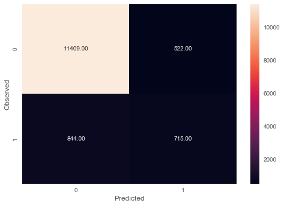

```python
y_entropyR_predict = model_entropyR.predict(X_test)

acc_DT = accuracy_score(y_test, y_entropyR_predict)
ent_recall = recall_score(y_test,y_entropyR_predict)
ent_precision = precision_score(y_test,y_entropyR_predict)
ent_f1_score = f1_score(y_test,y_entropyR_predict)
ent_roc = roc_auc_score(y_test,y_entropyR_predict)

draw_cm(y_test,y_entropyR_predict)
```

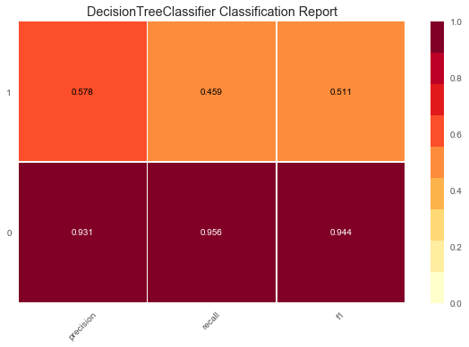

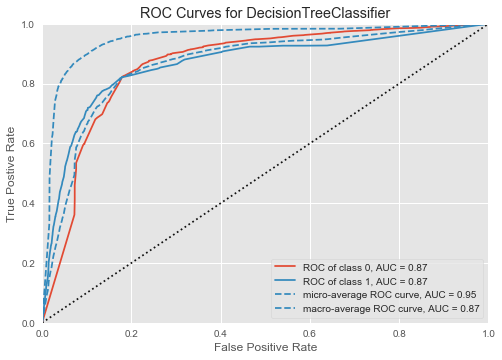

```python
viz = ClassificationReport(model_entropyR)
viz.fit(X_train, y_train)
viz.score(X_test, y_test)
viz.show()

roc = ROCAUC(model_entropyR)
roc.fit(X_train, y_train)
roc.score(X_test, y_test)
roc.show()
```

```python
tempResultsDf = pd.DataFrame({'Method':['Decision Tree'], 'accuracy': [acc_DT],'recall': [ent_recall], 'precision': [ent_precision], 'f1 score': [ent_f1_score], 'ROC AUC': [ent_roc]})
resultsDf = pd.concat([resultsDf, tempResultsDf])
resultsDf = resultsDf[['Method', 'accuracy', 'recall', 'precision', 'f1 score', 'ROC AUC']]
resultsDf
```

|  | Method | accuracy | recall | precision | f1 score | ROC AUC |
| --- | --- | --- | --- | --- | --- | --- |
| 0 | Logistic Regression | 0.8995 | 0.3258 | 0.6248 | 0.4283 | 0.6501 |
| 0 | Decision Tree | 0.8987 | 0.4586 | 0.5780 | 0.5114 | 0.7074 |

#### Both Logistic Regression and Decision tree have about a 90% accuracy. However the recall and f-score of the Decision Tree is better. Recall is important in our use case and so Decision Tree would be a better choice at this point. Improvng the Recall above the current 45.9% would also help our customer better.

### 3.2 Other Essemble Models

#### Random Forest

```python
from sklearn.ensemble import RandomForestClassifier
rfcl = RandomForestClassifier(n_estimators = 50, random_state=r_seed)
rfcl = rfcl.fit(X_train, y_train)
```

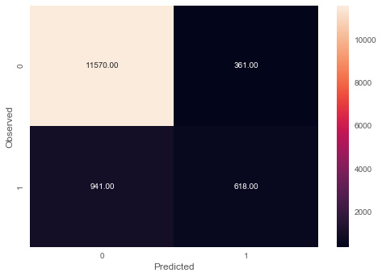

```python
pred_RF = rfcl.predict(X_test)
acc_RF = accuracy_score(y_test, pred_RF)

rf_recall = recall_score(y_test,pred_RF)
rf_precision = precision_score(y_test,pred_RF)
rf_f1_score = f1_score(y_test,pred_RF)
rf_roc = roc_auc_score(y_test,pred_RF)

draw_cm(y_test,pred_RF)
```

```python
tempResultsDf = pd.DataFrame({'Method':['Random Forest'], 'accuracy': [acc_RF],'recall': [rf_recall], 'precision': [rf_precision], 'f1 score': [rf_f1_score], 'ROC AUC': [rf_roc]})
resultsDf = pd.concat([resultsDf, tempResultsDf])
resultsDf = resultsDf[['Method', 'accuracy', 'recall', 'precision', 'f1 score', 'ROC AUC']]
resultsDf
```

|  | Method | accuracy | recall | precision | f1 score | ROC AUC |
| --- | --- | --- | --- | --- | --- | --- |
| 0 | Logistic Regression | 0.8995 | 0.3258 | 0.6248 | 0.4283 | 0.6501 |
| 0 | Decision Tree | 0.8987 | 0.4586 | 0.5780 | 0.5114 | 0.7074 |
| 0 | Random Forest | 0.9035 | 0.3964 | 0.6313 | 0.4870 | 0.6831 |

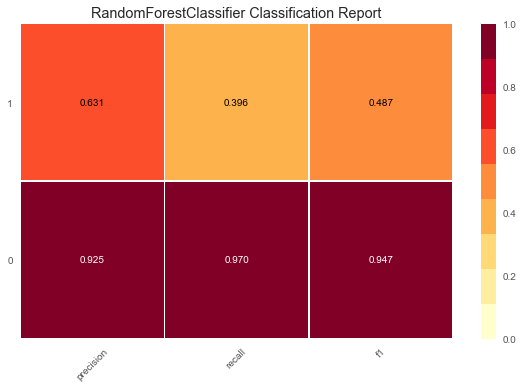

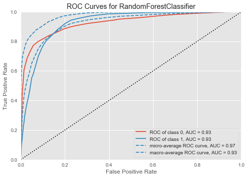

```python
# Visualize model performance with yellowbrick library
viz = ClassificationReport(rfcl)
viz.fit(X_train, y_train)
viz.score(X_test, y_test)
viz.show()

roc = ROCAUC(rfcl)
roc.fit(X_train, y_train)
roc.score(X_test, y_test)
roc.show()
```

#### Apply Adaboost Ensemble Algorithm for the same data and print the accuracy.

```python
from sklearn.ensemble import AdaBoostClassifier
abcl = AdaBoostClassifier(n_estimators = 100, learning_rate=0.1, random_state=r_seed)
abcl = abcl.fit(X_train, y_train)
```

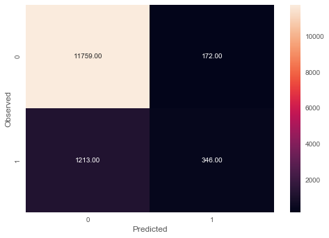

```python
pred_AB =abcl.predict(X_test)
acc_AB = accuracy_score(y_test, pred_AB)

ab_recall = recall_score(y_test,pred_AB)
ab_precision = precision_score(y_test,pred_AB)
ab_f1_score = f1_score(y_test,pred_AB)
ab_roc = roc_auc_score(y_test,pred_AB)

draw_cm(y_test,pred_AB)
```

```python
tempResultsDf = pd.DataFrame({'Method':['Adaboost'], 'accuracy': [acc_AB],'recall': [ab_recall], 'precision': [ab_precision], 'f1 score': [ab_f1_score], 'ROC AUC': [ab_roc]})
resultsDf = pd.concat([resultsDf, tempResultsDf])
resultsDf = resultsDf[['Method', 'accuracy', 'recall', 'precision', 'f1 score', 'ROC AUC']]
resultsDf
```

|  | Method | accuracy | recall | precision | f1 score | ROC AUC |
| --- | --- | --- | --- | --- | --- | --- |
| 0 | Logistic Regression | 0.8995 | 0.3258 | 0.6248 | 0.4283 | 0.6501 |
| 0 | Decision Tree | 0.8987 | 0.4586 | 0.5780 | 0.5114 | 0.7074 |
| 0 | Random Forest | 0.9035 | 0.3964 | 0.6313 | 0.4870 | 0.6831 |
| 0 | Adaboost | 0.8973 | 0.2219 | 0.6680 | 0.3332 | 0.6038 |

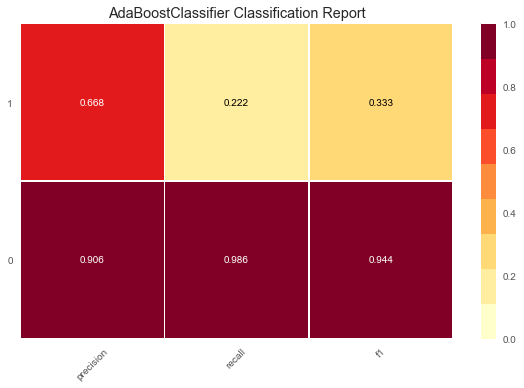

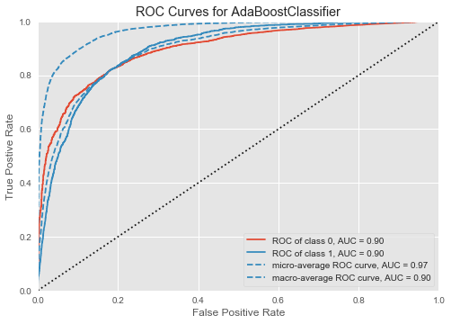

```python
# Visualize model performance with yellowbrick library
viz = ClassificationReport(abcl)
viz.fit(X_train, y_train)
viz.score(X_test, y_test)
viz.show()

roc = ROCAUC(abcl)
roc.fit(X_train, y_train)
roc.score(X_test, y_test)
roc.show()
```